# Series 6 – ANOVA & ANCOVA

Biostatistics Bayesian Methods R JAGS/Stan

A bit review ANOVA & ANCOVA in the Frequentist’s view  
“ANOVA & ANCOVA” in Bayesian Context  
Contrast Comparison

Hai Nguyen  
February 28, 2022

If we pay a bit attention to the ANOVA and ANCOVA, we can see the interesting point of views in these cases:

- they greatly depend on assumptions (homoscedastic, normally distributed)
- “Bayes” perhaps not call the terms ANOVA or ANCOVA. The analysis is based on linear regression’s hierarchical modeling with the restriction on some beta coefficient distributions. Thus, “Bayes” would call the metric response with nominal predictor with/without metric predictor.

# One-way ANOVA

This type of analysis actually is a model with metric output and one nominal predictor.

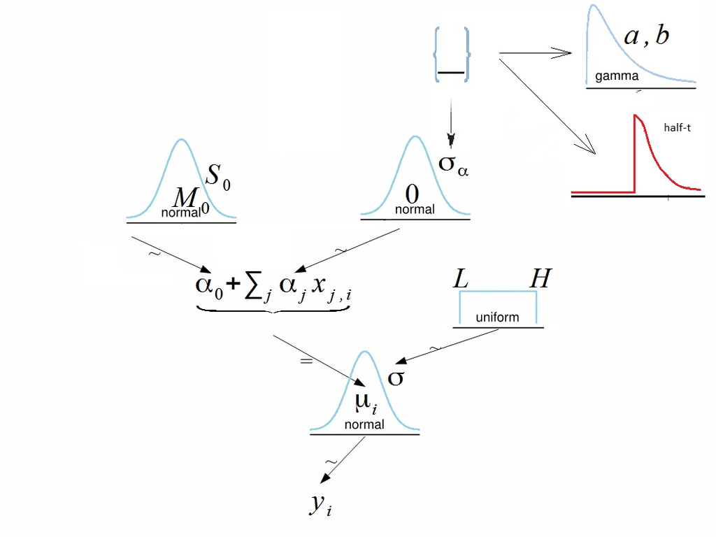

A diagram for metric output and one nominal predictor shows parameters denoted as $\alpha$ instead of traditional $\beta$.

We represent the nominal predictor by a vector $\vec{x}$ = {$x_{1}, ..., x_{J}$}, where $J$ is the number of categories that the predictor has. When an individual falls in group $j$ of the nominal predictor, this is represented by setting $x_{j} = 1$ and $x_{i\neq j} = 0$. The predicted value, denoted $\mu$, is the overall baseline plus the deflection of a group:

$$\begin{align*}
\mu &= \beta_0 + \sum_j \beta_{j} x_{j} \\
&= \beta_0 + \vec{\beta} \cdot \vec{x}
\end{align*}$$

The overall baseline is constrained so that the deflections sum to $0$ across the categories:
$$\sum_j \beta_{[j]} = 0$$

In order to satisfy this constraint, first, find unconstrained slopes $\alpha_1, ..., \alpha_J$ and then adjust them using formulas:

$$\begin{align*}
\mu &= \alpha_0 + \sum_j \alpha_{j} x_{j} \\
&= (\alpha_0 + \bar{\alpha}) + \sum_j (\alpha_{j} -
\bar{\alpha}) \cdot x_{j}\\
&= \beta_0 + \sum_j \beta_{j} x_{j}
\end{align*}$$

where $\bar{\alpha} = \frac{1}{n} \sum_j \alpha_j$

Interpretation of intercept is the grand mean value.

The standard deviation of slopes $\sigma_{\beta}$ may be either a constant or may have a prior of its own.

1. In case when $\sigma_{\beta}$ = const means of all groups are estimated separately, they do not inform each other through estimation of $\sigma_{\beta}$. A large number for $\sigma_{\beta}$ will make the results close or equivalent to ANOVA.
2. Giving $\sigma_{\beta}$ a prior affects shrinkage rate. If all group means are close to the grand mean then $\sigma_{\beta}$ is estimated as small number. This makes shrinkage stronger.

A key assumption behind estimating $\sigma_{\beta}$ from the data is that all groups can be meaningfully described as representatives of shared higher-level distribution.

**Example.** Giving $\sigma_{\beta}$ a prior distribution is not justified if, for example, in medical studies there are several control groups and one treated group. In this case small difference between placebo groups may result in significant shrinkage (bias) of the treated group.

In this example the treated group is an outlier. Heavy-tailed prior distribution for $\beta_j$ may help to overcome excessive shrinkage.

**Possible priors for $\sigma_{\alpha}$:**

- No prior, i.e. parameter is not estimated from the data. Estimated group means do not inform each other through $\sigma_{\alpha}$
- Gamma distribution or any other distribution concentrated on positive part of real line with shape allowing large deviations from zero
- Distributions on non-negative part of real line allowing large values, but also giving positive probability to zero value: half-Cauchy, folded t-distribution. Should be careful with this option since with small data set it may cause an implosive shrinkage.

Another interpretation of imploding shrinkage is: the model has to make choice between assigning more variability to between the groups ($\sigma_{\alpha}$) or shrinking the groups and assigning more variability to within the groups noise ($\sigma_{y}$).  
Whenever it is possible the model will prefer the latter.  
Shrinkage will not be very efficient in case of binary predictor.

## Sex and Death example of section 19.3 in (Kruschke 2015)

The fruit fly, Drosophila melanogaster, is known for this species that newly inseminated females will not remate (for at least two days), and males will not actively court pregnant females. There were 25 male fruit flies in each of the five groups.

`CompanionNumber`: group

- `None0`: males with zero companions
- `Pregnant1`: males with one pregnant female
- `Pregnant8`: males accompanied by eight pregnant females
- `Virgin1`: males accompanied by one virgin female
- `Virgin8`: males accompanied by eight virgin females

**Research Question:** estimate the life spans and the magnitude of differences between groups.

```r
#read the data, the file is available at [K].
dta <- read.csv("data/Fruitfly.csv")
names(dta)
```

```
[1] "Longevity"       "CompanionNumber" "Thorax"
```

```r
datatable(dta)
```

|  | Longevity | CompanionNumber | Thorax |
| --- | --- | --- | --- |
| 1 | 35 | Pregnant8 | 0.64 |
| 2 | 37 | Pregnant8 | 0.68 |
| 3 | 49 | Pregnant8 | 0.68 |
| 4 | 46 | Pregnant8 | 0.72 |
| 5 | 63 | Pregnant8 | 0.72 |
| 6 | 39 | Pregnant8 | 0.76 |
| 7 | 46 | Pregnant8 | 0.76 |
| 8 | 56 | Pregnant8 | 0.76 |
| 9 | 63 | Pregnant8 | 0.76 |
| 10 | 65 | Pregnant8 | 0.76 |

[output cut: 115 more lines]

## Traditional analysis

```r
library(tidyverse)
grMeans<-group_by(dta, CompanionNumber) %>%
  summarise(
    count = n(),
    mean = mean(Longevity, na.rm = TRUE),
    sd = sd(Longevity, na.rm = TRUE)
  )
levels(as.factor(dta$CompanionNumber))
```

```
[1] "None0"     "Pregnant1" "Pregnant8" "Virgin1"   "Virgin8"
```

```r
grMeans
```

```
# A tibble: 5 × 4
  CompanionNumber count  mean    sd
  <chr>           <int> <dbl> <dbl>
1 None0              25  63.6  16.5
2 Pregnant1          25  64.8  15.7
3 Pregnant8          25  63.4  14.5
4 Virgin1            25  56.8  14.9
5 Virgin8            25  38.7  12.1
```

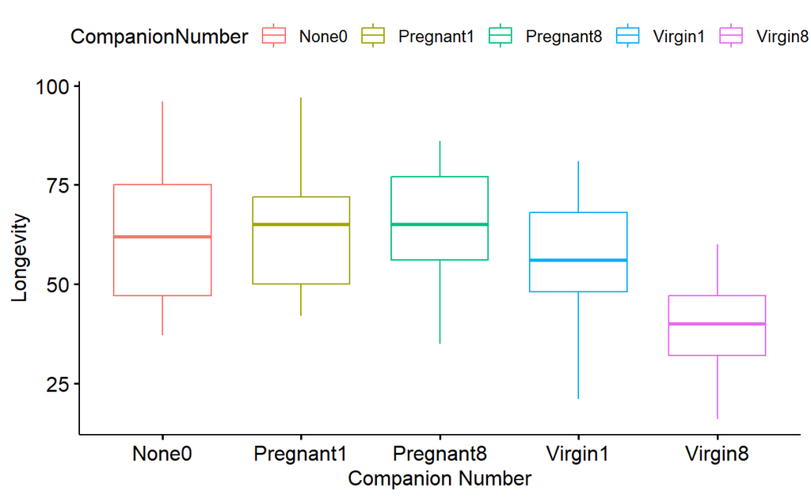

```r
# Box plots
# ++++++++++++++++++++
# Plot weight by group and color by group
library("ggpubr")
ggboxplot(dta, x = "CompanionNumber", y = "Longevity",
          color = "CompanionNumber",
          order = c("None0", "Pregnant1", "Pregnant8", "Virgin1", "Virgin8"),
          ylab = "Longevity", xlab = "Companion Number")
```

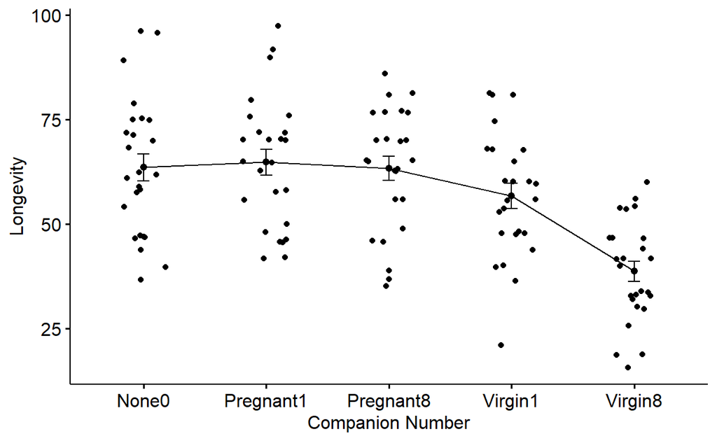

```r
ggline(dta, x = "CompanionNumber", y = "Longevity",
       add = c("mean_se", "jitter"),
       order = c("None0", "Pregnant1", "Pregnant8", "Virgin1", "Virgin8"),
       ylab = "Longevity", xlab = "Companion Number")
```

```r
# Compute the analysis of variance
longevity.aov <- aov(Longevity ~ CompanionNumber, data = dta)
# Summary of the analysis
summary(longevity.aov)
```

```
                 Df Sum Sq Mean Sq F value   Pr(>F)
CompanionNumber   4  11939  2984.8   13.61 3.52e-09 ***
Residuals       120  26314   219.3
---
Signif. codes:  0 '***' 0.001 '**' 0.01 '*' 0.05 '.' 0.1 ' ' 1
```

Interpret the result of one-way ANOVA tests:

As the p-value is less than the significance level $0.05$, we can conclude that there are significant differences between the groups highlighted with “***” in the model summary.

Tukey multiple pairwise-comparisons

As the ANOVA test is significant, we can compute Tukey HSD (Tukey Honest Significant Differences, R function: TukeyHSD()) for performing multiple pairwise-comparison between the means of groups.

The function TukeyHD() takes the fitted ANOVA as an argument.

```r
TukeyHSD(longevity.aov)
```

```
  Tukey multiple comparisons of means
    95% family-wise confidence level

Fit: aov(formula = Longevity ~ CompanionNumber, data = dta)

$CompanionNumber
                      diff       lwr        upr     p adj
Pregnant1-None0       1.24 -10.36047  12.840468 0.9983034
Pregnant8-None0      -0.20 -11.80047  11.400468 0.9999988
Virgin1-None0        -6.80 -18.40047   4.800468 0.4854206
Virgin8-None0       -24.84 -36.44047 -13.239532 0.0000003
Pregnant8-Pregnant1  -1.44 -13.04047  10.160468 0.9969591
Virgin1-Pregnant1    -8.04 -19.64047   3.560468 0.3126549
Virgin8-Pregnant1   -26.08 -37.68047 -14.479532 0.0000001
Virgin1-Pregnant8    -6.60 -18.20047   5.000468 0.5157692
Virgin8-Pregnant8   -24.64 -36.24047 -13.039532 0.0000004
Virgin8-Virgin1     -18.04 -29.64047  -6.439532 0.0003240
```

Check ANOVA assumptions: test validity?

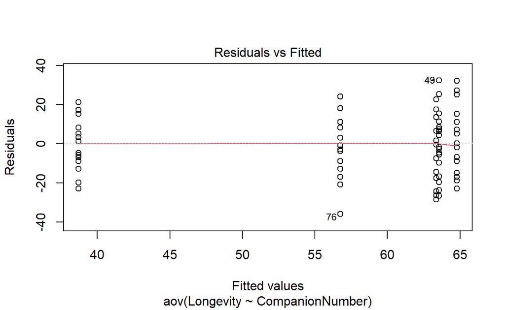

```r
# 1. Homogeneity of variances
plot(longevity.aov, 1)
```

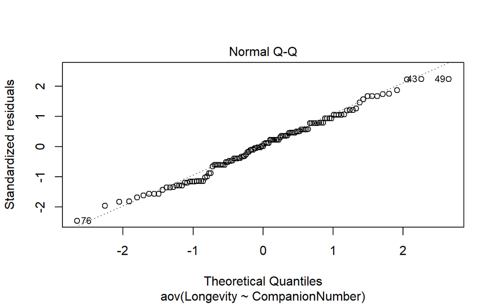

```r
# 2. Normality
plot(longevity.aov, 2)
```

```r
# Extract the residuals
aov_residuals <- residuals(object = longevity.aov )
# Run Shapiro-Wilk test
shapiro.test(x = aov_residuals ) #Shapiro-Wilk test on the ANOVA residuals (W = 0.99, p = 0.4) which finds no indication that normality is violated.
```

```
    Shapiro-Wilk normality test

data:  aov_residuals
W = 0.98887, p-value = 0.4088
```

A Shapiro-Wilk test on the ANOVA residuals (W = 0.99, p = 0.4) which finds no indication that normality is violated.

## Bayesian approach

```r
dataList <- list(Ntotal = nrow(dta),
                 y = dta$Longevity,
                 x = as.integer(as.factor(dta$CompanionNumber)),
                 NxLvl = nlevels(as.factor(dta$CompanionNumber)),
                 agammaShRa=unlist(gammaShRaFromModeSD(mode = sd(dta$Longevity)/2,
                                                       sd = 2*sd(dta$Longevity))))
```

Function `gammaShRaFromModeSD()` from the book calculates shape and rate parameters of gamma distribution from mode and standard deviation.

```r
#view source code of function gammaShRaFromModeSD()
gammaShRaFromModeSD
```

```
function (mode, sd)
{
    if (mode <= 0)
        stop("mode must be > 0")
    if (sd <= 0)
        stop("sd must be > 0")
    rate = (mode + sqrt(mode^2 + 4 * sd^2))/(2 * sd^2)
    shape = 1 + mode * rate
    return(list(shape = shape, rate = rate))
}
```

```r
(ShRa<-gammaShRaFromModeSD(mode=sd(dta$Longevity)/2,sd=2*sd(dta$Longevity)))
```

```
$shape
[1] 1.283196

$rate
[1] 0.03224747
```

With these parameters standard deviation of slopes is concentrated around a relatively small value 8.7819463, but has fat enough right tail.

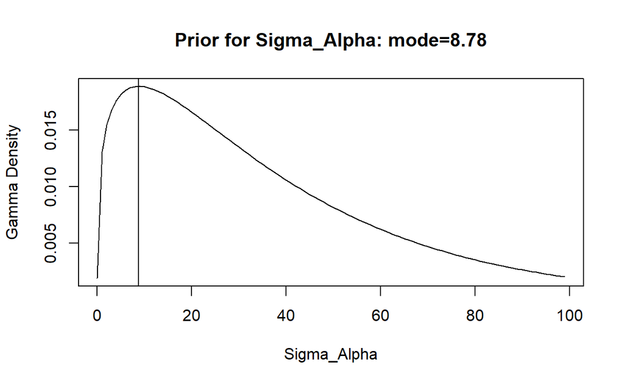

```r
xAxis <- seq(from=0.001, to=100, by=1 )
plot(xAxis, dgamma(xAxis, shape = ShRa$shape, rate = ShRa$rate), type='l',
     ylab="Gamma Density",xlab="Sigma_Alpha", main="Prior for Sigma_Alpha: mode=8.78")
abline(v=sd(dta$Longevity)/2)
```

Prepare the model description.

```r
modelString<-"
data {
    int<lower=1> Ntotal;
    real y[Ntotal];
    int<lower=2> NxLvl;
    int<lower=1, upper=NxLvl> x[Ntotal];
    real<lower=0> agammaShRa[2];
}
transformed data {
    real meanY;
    real sdY;
    meanY = mean(y);
    sdY = sd(y);
}
parameters {
    real a0;
    real<lower=0> aSigma;
    vector[NxLvl] a;
    real<lower=0> ySigma;
}
model {
    a0 ~ normal(meanY, 5*sdY);
    aSigma ~ gamma(agammaShRa[1], agammaShRa[2]);
    a ~ normal(0, aSigma);
    ySigma ~ uniform(sdY/100, sdY*10);
    for ( i in 1:Ntotal ) {
        y[i] ~ normal(a0 + a[x[i]], ySigma);
    }
}
generated quantities {
    // Convert a0,a[] to sum-to-zero b0,b[] :
        real b0;
    vector[NxLvl] b;
    b0 = a0 + mean(a);
    b = a - mean(a);
}"
```

Run MCMC.

```r
stanDso <- stan_model(model_code = modelString)
```

If saved DSO is used load it, then run the chains.

```r
# saveRDS(stanDso,file="data/stanDSO.Rds")
stanDso <- readRDS("data/stanDSO.Rds")
```

```r
fit <- sampling(stanDso,
                data = dataList,
                pars = c('b0', 'b', 'aSigma', 'ySigma'),
                iter = 5000, chains = 2, cores = 4)
```

Analyze the chains using `shinystan()`

```r
launch_shinystan(fit)
```

```r
summary(fit)$summary[,c(1,4,6,8,10)]
```

```
               mean         2.5%          50%      97.5%      Rhat
b0       57.4393525   54.8635804   57.4343609   60.01657 1.0001866
b[1]      5.7588760    0.5134606    5.7673484   10.97372 0.9999060
b[2]      6.9174882    1.8407142    6.8867440   12.16411 0.9999481
b[3]      5.5581312    0.4278215    5.5290942   10.80727 0.9997391
b[4]     -0.5954606   -5.7719881   -0.5929975    4.69568 1.0000531
b[5]    -17.6390348  -22.7535663  -17.6253508  -12.37578 1.0002923
aSigma   15.4223486    6.3137021   13.3207333   37.62849 1.0021829
ySigma   14.9461756   13.2475061   14.9014775   16.95289 1.0005380
lp__   -409.5860642 -414.8603961 -409.2042069 -406.39237 1.0017972
```

```r
cbind(GroupMeans=grMeans,
      EstimatedMeans=summary(fit)$summary[2:6,1]+summary(fit)$summary[1,1])
```

```
     GroupMeans.CompanionNumber GroupMeans.count GroupMeans.mean
b[1]                      None0               25           63.56
b[2]                  Pregnant1               25           64.80
b[3]                  Pregnant8               25           63.36
b[4]                    Virgin1               25           56.76
b[5]                    Virgin8               25           38.72
     GroupMeans.sd EstimatedMeans
b[1]      16.45215       63.19823
b[2]      15.65248       64.35684
b[3]      14.53983       62.99748
b[4]      14.92838       56.84389
b[5]      12.10207       39.80032
```

Note differences between estimated group means and also shrinkage.

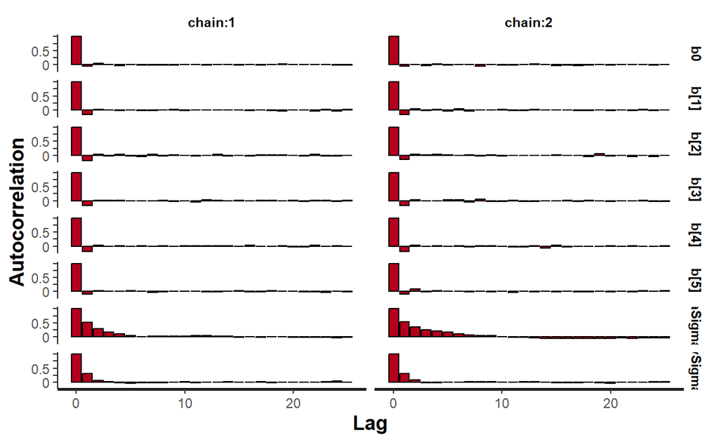

```r
stan_ac(fit, separate_chains = T)
```

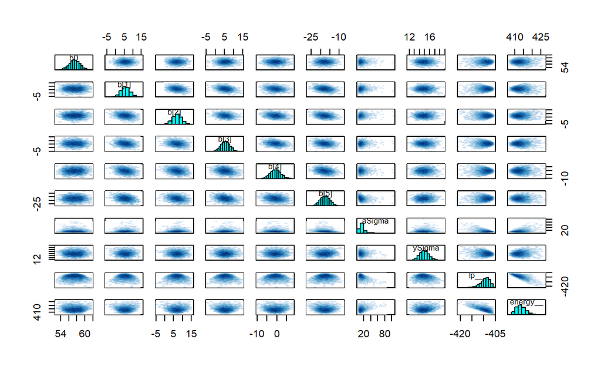

```r
pairs(fit)
```

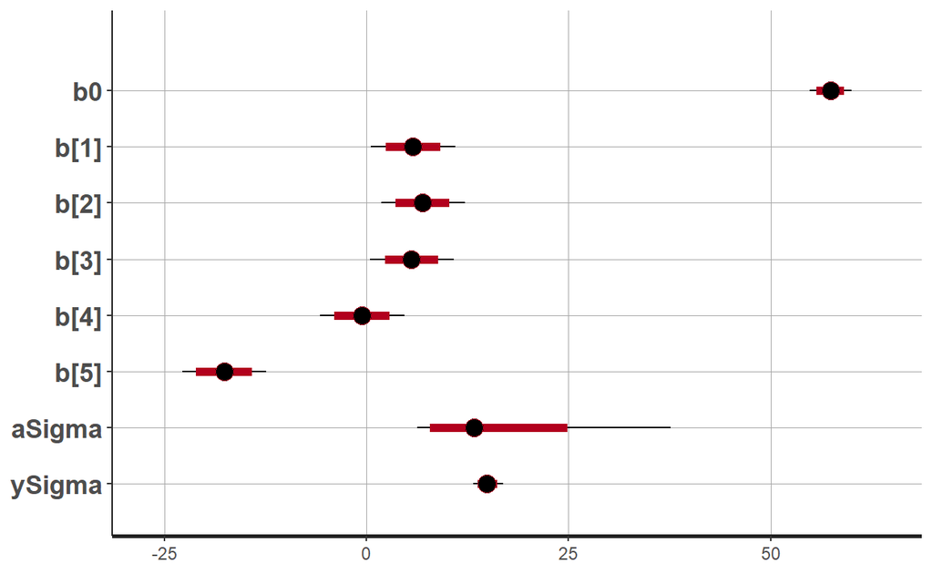

```r
plot(fit)
```

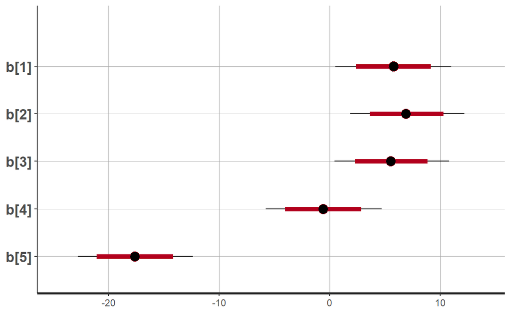

```r
plot(fit,pars=c("b"))
```

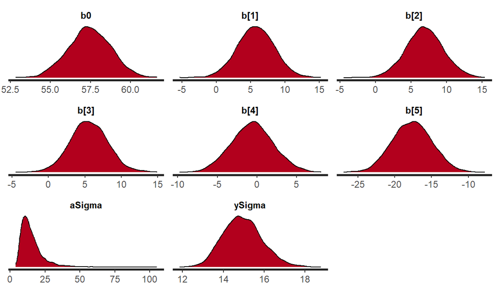

```r
stan_dens(fit)
```

From MCMC we see immediately that not all parameters $\beta_j$ are zeros (omnibus test).  
As usual, the following question in ANOVA is: which group means are not equal.  
To answer this question we use contrasts.

In FNP approach there is a constraint on how many pairs or subgroups can be checked with contrasts with desired accuracy of inference.

In Bayesian approach testing of contrasts is straight forward and does not have restrictions: each step of chain returns a combination of group means. Thus we only need to compare frequency of these combinations in the chain.

Calculate contrasts for `betas`.

Extract chains for parameters `b`.

```r
fit_ext <- rstan::extract(fit)
head(fit_ext$b)
```

```
iterations     [,1]       [,2]     [,3]       [,4]      [,5]
      [1,] 7.477280  3.4507237 6.191515 -4.0575910 -13.06193
      [2,] 3.379211 12.8289133 5.852268  0.1562871 -22.21668
      [3,] 7.777005  0.5933093 6.875631  0.7496060 -15.99555
      [4,] 6.199593  4.9381578 5.802773  2.4810871 -19.42161
      [5,] 8.107023  4.9390397 6.255589 -1.3545609 -17.94709
      [6,] 5.496331  7.7539725 9.307447 -5.7502948 -16.80746
```

```r
dim(fit_ext$b)
```

```
[1] 5000    5
```

1. Contrast between group 1 (‘None0’) and group 5 (‘Virgin8’)

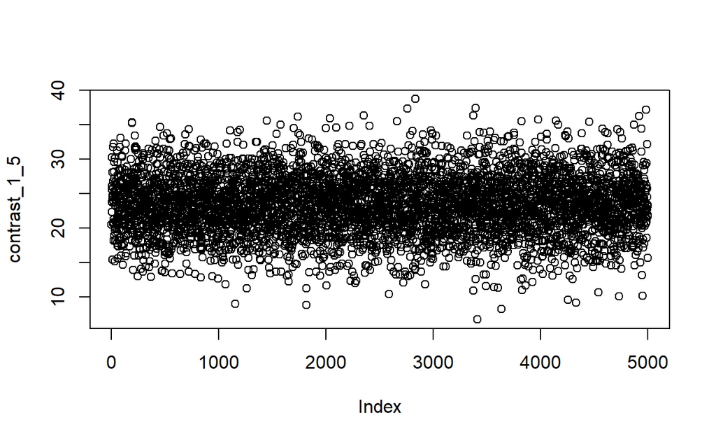

```r
contrast_1_5 <- fit_ext$b[,1] - fit_ext$b[,5]
plot(contrast_1_5)
```

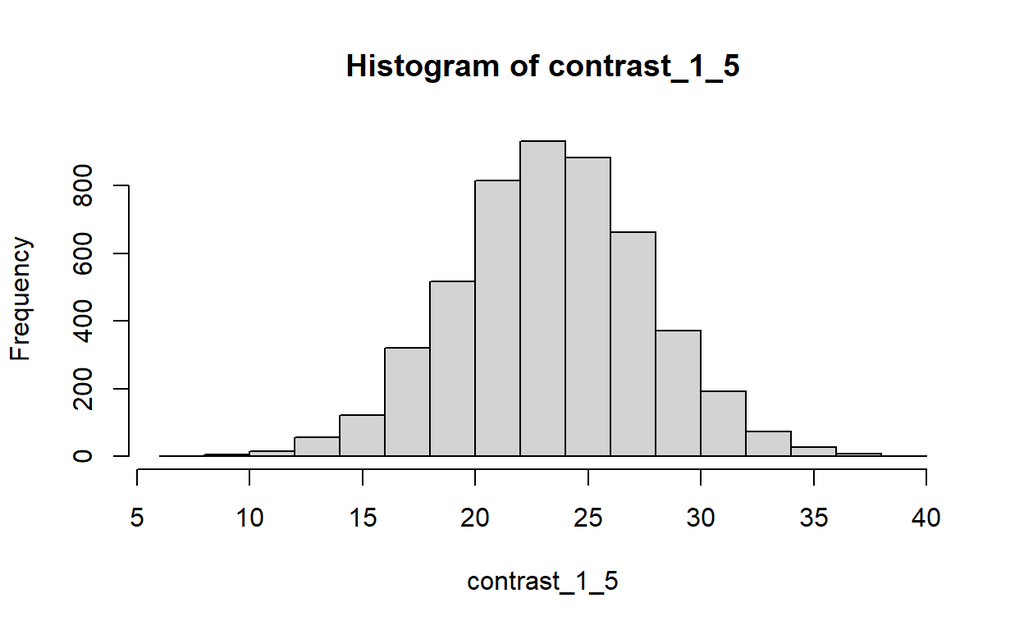

```r
hist(contrast_1_5)
```

```r
(hdiContrast_1_5 <- hdi(contrast_1_5))
```

```
   lower    upper
15.21982 31.95605
attr(,"credMass")
[1] 0.95
```

```r
(sd.contrast_1_5 <- sd(contrast_1_5))
```

```
[1] 4.256989
```

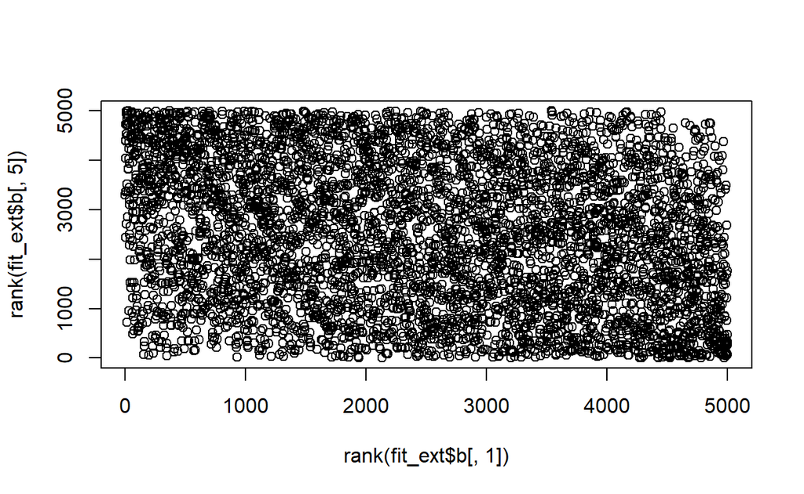

```r
plot(rank(fit_ext$b[,1]), rank(fit_ext$b[,5]))
```

2. Contrast between average of groups 1-3 (None0, Pregnant1, Pregnant8) and average of groups 4-5 (Virgin1, Virgin8)

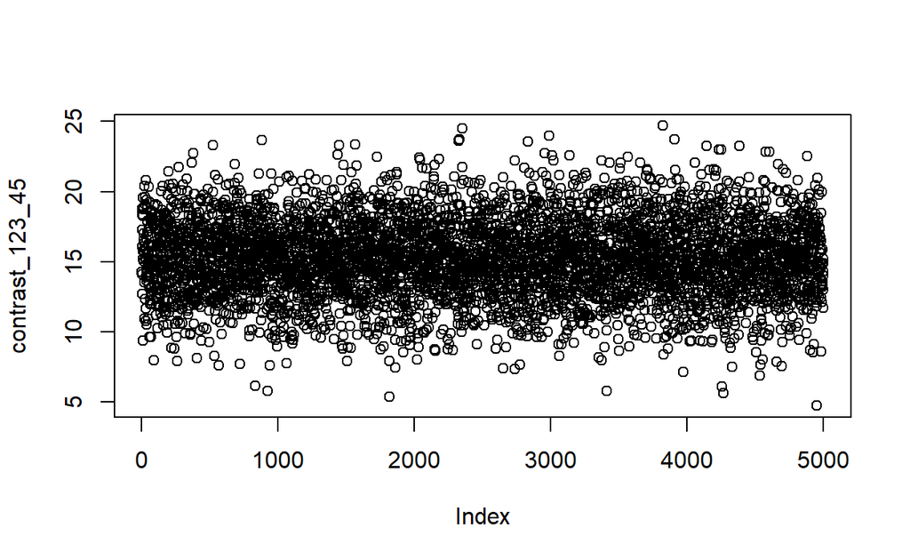

```r
Comb1<-(fit_ext$b[,1] + fit_ext$b[,2] + fit_ext$b[,3])/3
Comb2<-(fit_ext$b[,4] + fit_ext$b[,5])/2
contrast_123_45 <- Comb1 - Comb2
plot(contrast_123_45)
```

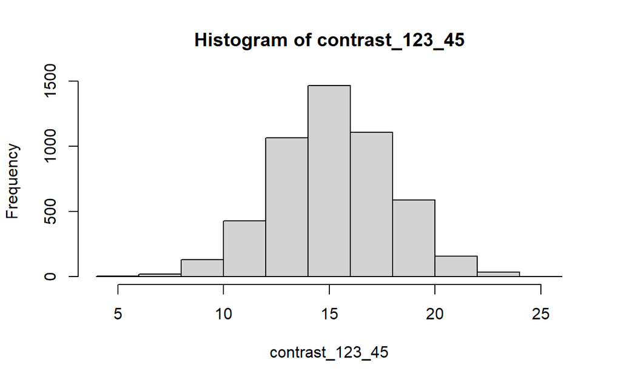

```r
hist(contrast_123_45)
```

```r
(hdiContrast_123_45<-hdi(contrast_123_45))
```

```
    lower     upper
 9.713508 20.416612
attr(,"credMass")
[1] 0.95
```

```r
(sd.contrast_123_45<-sd(contrast_123_45))
```

```
[1] 2.734301
```

```r
head(cbind(Comb1,Comb2))
```

```
        Comb1      Comb2
[1,] 5.706506  -8.559759
[2,] 7.353464 -11.030196
[3,] 5.081982  -7.622973
[4,] 5.646841  -8.470262
[5,] 6.433884  -9.650826
[6,] 7.519250 -11.278875
```

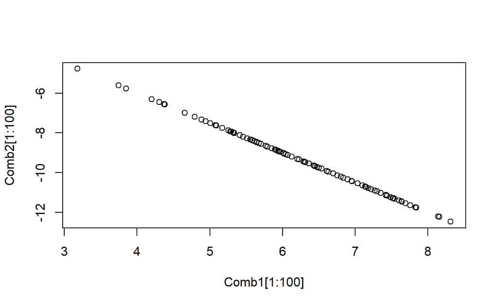

```r
plot(Comb1[1:100],Comb2[1:100])
```

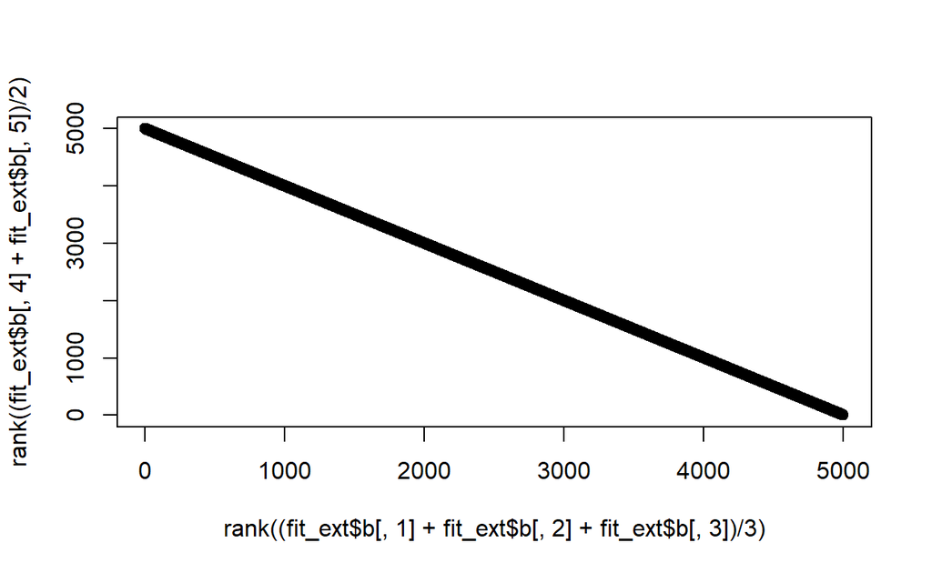

```r
plot(rank((fit_ext$b[,1] + fit_ext$b[,2] + fit_ext$b[,3])/3),rank((fit_ext$b[,4] + fit_ext$b[,5])/2))
```

# Two-way ANOVA

## Model description

Define the model

```r
modelString<-"
data {
    int<lower=1> Ntotal;
    vector[Ntotal] y;
    int<lower=2> Nx1Lvl;
    int<lower=2> Nx2Lvl;
    int<lower=1, upper=Nx1Lvl> x1[Ntotal];
    int<lower=1, upper=Nx2Lvl> x2[Ntotal];
    real<lower=0> agammaShRa[2];
}
transformed data {
    real meanY;
    real sdY;
    vector[Ntotal] zy;
    meanY = mean(y);
    sdY = sd(y);
    zy = (y - mean(y)) / sdY;  // center & normalize
}
parameters {
    real a0;
    real<lower=0> a1Sigma;
    real<lower=0> a2Sigma;
    real<lower=0> a1a2Sigma;
    vector[Nx1Lvl] a1;
    vector[Nx2Lvl] a2;
    matrix[Nx1Lvl,Nx2Lvl] a1a2;
    real<lower=0> zySigma;
}
model {
    a0 ~ normal(0, 1);
    a1Sigma ~ gamma(agammaShRa[1], agammaShRa[2]);
    a1 ~ normal(0, a1Sigma);
    a2Sigma ~ gamma(agammaShRa[1], agammaShRa[2]);
    a2 ~ normal(0, a2Sigma);
    a1a2Sigma ~ gamma(agammaShRa[1], agammaShRa[2]);
    for (j1 in 1:Nx1Lvl) {
        a1a2[j1,] ~ normal(0, a1a2Sigma);
    }
    zySigma ~ uniform(1.0/10, 10);
    for ( i in 1:Ntotal ) {
        zy[i] ~ normal(a0 + a1[x1[i]] + a2[x2[i]]+ a1a2[x1[i],x2[i]], zySigma);
    }
}
generated quantities {
    // Convert a to sum-to-zero b :
    real b0;
    vector[Nx1Lvl] b1;
    vector[Nx2Lvl] b2;
    matrix[Nx1Lvl,Nx2Lvl] b1b2;
    matrix[Nx1Lvl,Nx2Lvl] m;
    real<lower=0> b1Sigma;
    real<lower=0> b2Sigma;
    real<lower=0> b1b2Sigma;
    real<lower=0> ySigma;
    for ( j1 in 1:Nx1Lvl ) { for ( j2 in 1:Nx2Lvl ) {
        m[j1,j2] = a0 + a1[j1] + a2[j2] + a1a2[j1,j2]; // cell means
    } }
    b0 = mean(m);
    for ( j1 in 1:Nx1Lvl ) { b1[j1] = mean( m[j1,] ) - b0; }
    for ( j2 in 1:Nx2Lvl ) { b2[j2] = mean( m[,j2] ) - b0; }
    for ( j1 in 1:Nx1Lvl ) { for ( j2 in 1:Nx2Lvl ) {
        b1b2[j1,j2] = m[j1,j2] - ( b0 + b1[j1] + b2[j2] );
    } }
    // transform to original scale:
    b0 = meanY + sdY * b0;
    b1 = sdY * b1;
    b2 = sdY * b2;
    b1b2 = sdY * b1b2;
    b1Sigma = sdY * a1Sigma;
    b2Sigma = sdY * a2Sigma;
    b1b2Sigma = sdY * a1a2Sigma;
    ySigma = sdY * zySigma;
}"
```

```r
#Create DSO.
stanDsoANOVA2Way <- stan_model(model_code=modelString)
```

```r
#If saved DSO is used load it, then run the chains.
# saveRDS(stanDsoANOVA2Way,file="data/stanDso2WayANOVA.Rds")
stanDsoANOVA2Way <- readRDS(file="data/stanDso2WayANOVA.Rds")
```

## Data of section 20.1 in (Kruschke 2015)

Read the data.

The data show faculty salaries of a university.

The columns selected as predictors are:

Position (Assistant Professor, Associate Professor, Full Professor, Full Professor with endowment salary and Distinguished Professor) Department (total 60 departments)

```r
# 20_1: Metric Predicted Variable with Two Nominal Predictors

# load data from 'Salary.csv' (see Kruschke)
df <- read.csv("data/Salary.csv")
mean(df$Salary)
```

```
[1] 110452
```

```r
tail(df)
```

```
      Org                                  OrgName Cla Pos ClaPos
1075 OADT Business Operations & Decision Technolog  PT FT3 PT.FT3
1076 CSCI                         Computer Science  PT FT3 PT.FT3
1077 PHYS                                  Physics  PT FT3 PT.FT3
1078 GEOL                      Geological Sciences  PR FT1 PR.FT1
1079   BI                                  Biology  PR FT1 PR.FT1
1080 MUST           Music School-String Technology  PR FT1 PR.FT1
     Salary
1075 147400
1076  92500
1077  76748
1078 105786
1079 116592
1080 138022
```

```r
dim(df)
```

```
[1] 1080    6
```

```r
names(df)
```

```
[1] "Org"     "OrgName" "Cla"     "Pos"     "ClaPos"  "Salary"
```

```r
with(df, table(Pos))
```

```
Pos
DST FT1 FT2 FT3 NDW
 32 360 364 240  84
```

```r
with(df, table(Org))
```

```
Org
ACTG AFRO AMST ANTH APHS  AST BEPP BFIN   BI BLAN CEDP CEUS CHEM CMCL
  19    7    7   23   18    7    9   21   51    7   25   11   35   17
CMLT CRIN CSCI EALC ECON ELPS  ENG FINH FINS FOLK FRIT GEOG GEOL GERM
   8   23   30   14   20   16   39    9   14   11   14    8   19    9
HIST INFO JOUR KINE LAWS LGED LING MATH MGMT MKTG MUHI MUIN MUST MUTH
  35   20   14   15   37   11    8   40   12   13    9   38   14    8
MUVO OADT  OPT PHYS   PL POLS  PSY  REL RPAD SLIS  SLS  SOC SPAN SPEA
  10   14   11   32   14   22   41   13   10   13    7   20   21   40
SPHS STAT TELC THTR
  15    7   12   13
```

```r
length(table(df$Org))
```

```
[1] 60
```

```r
y <- df$Salary
x1 <- as.factor(df$Pos)
x2 <- as.factor(df$Org)
str(df)
```

```
'data.frame':   1080 obs. of  6 variables:
 $ Org    : chr  "PL" "MUTH" "ENG" "CMLT" ...
 $ OrgName: chr  "Philosophy" "Music Theory" "English" "Comparative Literature" ...
 $ Cla    : chr  "PC" "PC" "PC" "PC" ...
 $ Pos    : chr  "FT2" "FT2" "FT2" "FT2" ...
 $ ClaPos : chr  "PC.FT2" "PC.FT2" "PC.FT2" "PC.FT2" ...
 $ Salary : int  72395 61017 82370 68805 63796 219600 98814 107745 114275 173302 ...
```

```r
dataListSalary <- list(Ntotal=length(y),
                       y=y,
                       x1=as.integer(x1),
                       x2=as.integer(x2),
                       Nx1Lvl=nlevels(x1),
                       Nx2Lvl=nlevels(x2),
                       agammaShRa=unlist(gammaShRaFromModeSD(mode=1/2, sd=2)))
```

Create names of variables and their interactions

```r
(namesPos<-names(table(df$Pos)))
```

```
[1] "DST" "FT1" "FT2" "FT3" "NDW"
```

```r
(namesOrg<-names(table(df$Org)))
```

```
 [1] "ACTG" "AFRO" "AMST" "ANTH" "APHS" "AST"  "BEPP" "BFIN" "BI"
[10] "BLAN" "CEDP" "CEUS" "CHEM" "CMCL" "CMLT" "CRIN" "CSCI" "EALC"
[19] "ECON" "ELPS" "ENG"  "FINH" "FINS" "FOLK" "FRIT" "GEOG" "GEOL"
[28] "GERM" "HIST" "INFO" "JOUR" "KINE" "LAWS" "LGED" "LING" "MATH"
[37] "MGMT" "MKTG" "MUHI" "MUIN" "MUST" "MUTH" "MUVO" "OADT" "OPT"
[46] "PHYS" "PL"   "POLS" "PSY"  "REL"  "RPAD" "SLIS" "SLS"  "SOC"
[55] "SPAN" "SPEA" "SPHS" "STAT" "TELC" "THTR"
```

Interactions names:

```r
#use outer() to create names for interactions.
as.vector(outer(1:4,1:2,paste,sep="-"))
```

```
[1] "1-1" "2-1" "3-1" "4-1" "1-2" "2-2" "3-2" "4-2"
```

```r
#apply to our case
(namesInter<-as.vector(outer(namesOrg,namesPos,paste,sep="-")))
```

```
  [1] "ACTG-DST" "AFRO-DST" "AMST-DST" "ANTH-DST" "APHS-DST"
  [6] "AST-DST"  "BEPP-DST" "BFIN-DST" "BI-DST"   "BLAN-DST"
 [11] "CEDP-DST" "CEUS-DST" "CHEM-DST" "CMCL-DST" "CMLT-DST"
 [16] "CRIN-DST" "CSCI-DST" "EALC-DST" "ECON-DST" "ELPS-DST"
 [21] "ENG-DST"  "FINH-DST" "FINS-DST" "FOLK-DST" "FRIT-DST"
 [26] "GEOG-DST" "GEOL-DST" "GERM-DST" "HIST-DST" "INFO-DST"
 [31] "JOUR-DST" "KINE-DST" "LAWS-DST" "LGED-DST" "LING-DST"
 [36] "MATH-DST" "MGMT-DST" "MKTG-DST" "MUHI-DST" "MUIN-DST"
 [41] "MUST-DST" "MUTH-DST" "MUVO-DST" "OADT-DST" "OPT-DST"
 [46] "PHYS-DST" "PL-DST"   "POLS-DST" "PSY-DST"  "REL-DST"
 [51] "RPAD-DST" "SLIS-DST" "SLS-DST"  "SOC-DST"  "SPAN-DST"
 [56] "SPEA-DST" "SPHS-DST" "STAT-DST" "TELC-DST" "THTR-DST"
 [61] "ACTG-FT1" "AFRO-FT1" "AMST-FT1" "ANTH-FT1" "APHS-FT1"
 [66] "AST-FT1"  "BEPP-FT1" "BFIN-FT1" "BI-FT1"   "BLAN-FT1"
 [71] "CEDP-FT1" "CEUS-FT1" "CHEM-FT1" "CMCL-FT1" "CMLT-FT1"
```

[output cut: 45 more lines]

```r
#all names:
varNames<-c("Intercept", namesPos, namesOrg, namesInter, rep("Var",5)) #why need to rep Var 5 times
```

## MCMC

```r
# fit model
fit <- sampling(stanDsoANOVA2Way,
                data=dataListSalary,
                pars=c('b0',
                       'b1',
                       'b2',
                       'b1b2',
                       'b1Sigma',
                       'b2Sigma',
                       'b1b2Sigma',
                       'ySigma'),
                iter=5000, chains = 2, cores = 4)
```

```r
# save(fit, file = "data/fitinstan1.Rdata")
load("data/fitinstan1.Rdata")
```

```r
launch_shinystan(fit)
```

Create results including mean value, 2.5%, 50% and 97.5% quantiles. Add variable names as row names.

```r
SalaryResults <- summary(fit)$summary[,c(1,4,6,8)]
varNames[nrow(SalaryResults)-(4:0)] <- rownames(SalaryResults)[nrow(SalaryResults)-(4:0)]
rownames(SalaryResults) <- varNames
head(SalaryResults)
```

```
                mean       2.5%        50%       97.5%
Intercept 127090.073 124721.828 127081.992 129373.0577
DST        55548.126  48387.941  55571.959  62569.1969
FT1        -3101.583  -5949.631  -3126.253   -148.3999
FT2       -33047.754 -35838.531 -33046.367 -30203.8486
FT3       -46367.618 -49353.221 -46385.131 -43252.7522
NDW        26968.829  22202.907  26981.535  31482.3894
```

Make plots of mean values and HDIs.

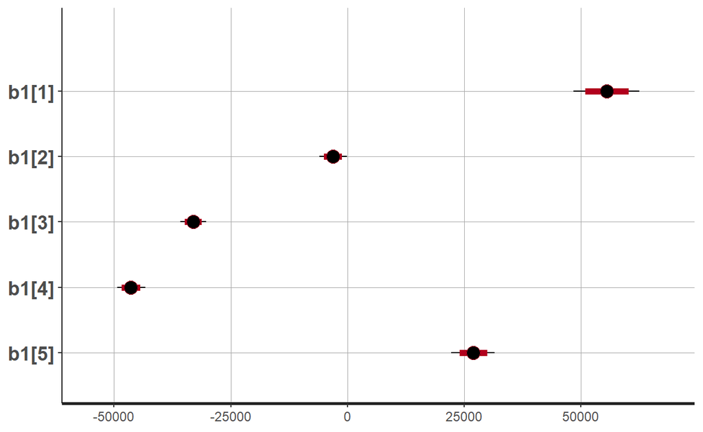

```r
plot(fit,pars=c("b1"))
```

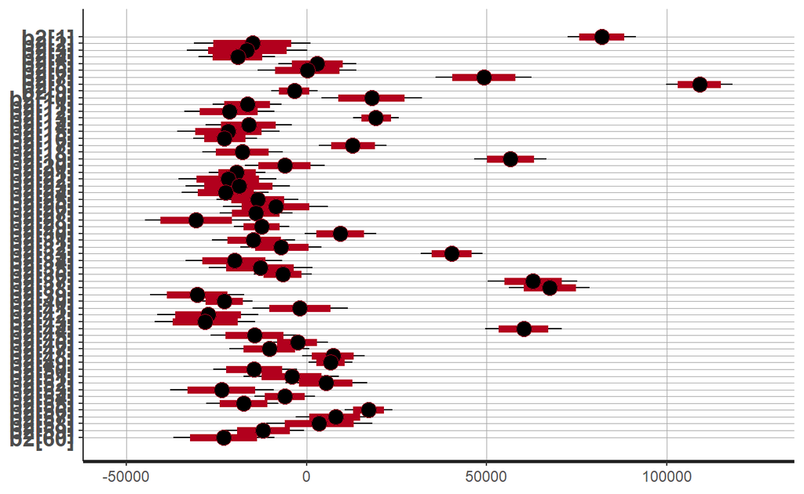

```r
plot(fit,pars=c('b2'))
```

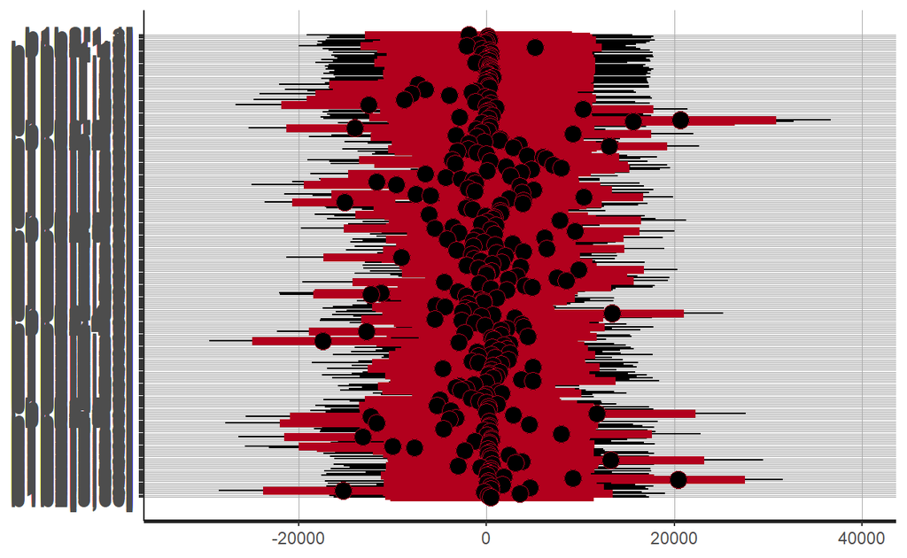

```r
plot(fit,pars=c("b1b2"))
```

Plots show that not all coefficients of the model equal zero. This answers the question of utility test.

## Working with chains and contrasts

Extract chains for the position variables.

```r
fit_ext <- rstan::extract(fit)
names(fit_ext)
```

```
[1] "b0"        "b1"        "b2"        "b1b2"      "b1Sigma"
[6] "b2Sigma"   "b1b2Sigma" "ySigma"    "lp__"
```

```r
fit_ext.b0<-fit_ext$b0
fit_ext.b1<-fit_ext$b1
colnames(fit_ext.b1) <- namesPos
head(fit_ext.b1)
```

```
iterations      DST       FT1       FT2       FT3      NDW
      [1,] 53643.51 -2464.063 -32308.67 -48308.55 29437.76
      [2,] 58738.28 -1706.306 -33827.16 -46158.53 22953.73
      [3,] 55505.48 -3764.629 -31670.52 -44799.95 24729.62
      [4,] 53497.58 -4276.004 -31554.91 -48626.05 30959.38
      [5,] 57104.01 -2315.971 -34761.95 -48452.81 28426.72
      [6,] 57498.84 -2508.874 -33852.21 -47274.01 26136.25
```

Extract chains for the department variables.

```r
fit_ext.b2 <- fit_ext$b2
colnames(fit_ext.b2) <- namesOrg
head(fit_ext.b2)
```

```
iterations     ACTG       AFRO        AMST       ANTH        APHS
      [1,] 84518.72 -10683.803 -31817.1077  -4720.261   3396.7104
      [2,] 88156.40 -12387.445    836.3933 -20495.377 -11482.3619
      [3,] 81611.69 -13618.307 -28257.8104 -18097.996  11482.2086
      [4,] 79194.53 -21153.965 -15077.6255 -21260.863   -125.4459
      [5,] 85622.17 -25296.108 -18530.4846 -20764.400    564.3309
      [6,] 82473.44  -3693.756 -14717.9823 -22886.365   6663.3884

iterations        AST     BEPP      BFIN        BI     BLAN      CEDP
      [1,]  -272.2711 56966.20 113408.94 -6397.807 24797.14 -23240.80
      [2,]  8032.0282 50815.51 108789.31 -2003.753 23891.55 -22317.59
      [3,] -4209.3496 54267.00 105146.37 -9549.098 14526.17 -11514.01
      [4,]  8876.8401 30764.92  99360.17  2224.069 15125.27 -20714.19
      [5,]  8044.0916 46878.48 118933.83 -2619.729 10774.34 -13026.26
      [6,]  7926.3391 46454.59 109490.48 -2284.006 24635.29 -21256.39
```

[output cut: 80 more lines]

Extract chains for interaction variables.

```r
fit_ext.b1.b2<-fit_ext$b1b2
dim(fit_ext.b1.b2)
```

```
[1] 5000    5   60
```

Interaction chains make a cube.

```r
dimnames(fit_ext.b1.b2)[[2]]<-namesPos
dimnames(fit_ext.b1.b2)[[3]]<-namesOrg
dimnames(fit_ext.b1.b2)
```

```
$iterations
NULL

[[2]]
[1] "DST" "FT1" "FT2" "FT3" "NDW"

[[3]]
 [1] "ACTG" "AFRO" "AMST" "ANTH" "APHS" "AST"  "BEPP" "BFIN" "BI"
[10] "BLAN" "CEDP" "CEUS" "CHEM" "CMCL" "CMLT" "CRIN" "CSCI" "EALC"
[19] "ECON" "ELPS" "ENG"  "FINH" "FINS" "FOLK" "FRIT" "GEOG" "GEOL"
[28] "GERM" "HIST" "INFO" "JOUR" "KINE" "LAWS" "LGED" "LING" "MATH"
[37] "MGMT" "MKTG" "MUHI" "MUIN" "MUST" "MUTH" "MUVO" "OADT" "OPT"
[46] "PHYS" "PL"   "POLS" "PSY"  "REL"  "RPAD" "SLIS" "SLS"  "SOC"
[55] "SPAN" "SPEA" "SPHS" "STAT" "TELC" "THTR"
```

```r
fit_ext.b1.b2[1,,]
```

```
            ACTG      AFRO      AMST      ANTH        APHS        AST
  DST   3539.479  6393.899  1304.058 15763.611 -10799.0416   7927.158
  FT1 -16326.820 -7421.503 -6828.542 -9787.681  11662.4623  -2611.558
  FT2   9626.651 -4519.507  3486.851 -9088.313  -2036.0353   2425.408
  FT3   8239.038 -2385.126 10078.649  3483.160   -975.3569 -13603.240
  NDW  -5078.347  7932.237 -8041.017  -370.778   2147.9715   5862.232

           BEPP        BFIN        BI       BLAN       CEDP      CEUS
  DST  8728.384  -2330.6655 -2834.672 -5466.1952 -15580.544 -2080.820
  FT1 -3538.370    976.2805  4358.263 -2541.3345  -1900.758  1838.315
  FT2  4630.186  12267.9786 -5681.101  -673.3443   4958.960  4207.809
  FT3 -2312.500   1773.3809 12940.011  1518.5936   9637.629  5874.503
  NDW -7507.699 -12686.9744 -8782.501  7162.2803   2884.713 -9839.807

            CHEM      CMCL         CMLT      CRIN       CSCI
  DST   3002.086 -9440.742    -86.93006 -9140.478  3129.8086
  FT1  11524.040 14411.093  -2557.61581 -3161.343 -2309.5690
  FT2  -5293.531 -2668.087 -16853.21654  6077.927 -7840.4627
  FT3 -22330.841 -7414.901   7430.17731 10001.465   422.3283
  NDW  13098.245  5112.637  12067.58510 -3777.572  6597.8948

           EALC        ECON       ELPS         ENG       FINH
  DST -4167.890   -258.8566  -721.5942   -692.6053 -4837.1791
  FT1  7427.198   5254.3375  3062.8163   2486.2253 -9159.9057
  FT2  6582.357  12117.9070 -4679.8036   5590.4990 17244.9910
  FT3 -3181.338 -22080.7613 -2932.5083   4007.1760 -2496.7910
  NDW -6660.328   4967.3734  5271.0899 -11391.2951  -751.1152

            FINS      FOLK       FRIT       GEOG        GEOL
  DST   325.8752 -3893.956  -6294.419  6675.0396   5774.6693
  FT1   535.5009 -7072.318  17389.175  7479.6932  12352.3715
  FT2  -328.2188  4064.460 -15657.924 -6928.5509   2648.6372
  FT3 -7741.0741  9117.089   6343.980  -701.5859    466.6109
  NDW  7207.9169 -2215.275  -1780.812 -6524.5961 -21242.2889

           GERM      HIST        INFO      JOUR       KINE
  DST  4706.445 -8527.565   3237.7335 -1757.081 -10582.306
  FT1 -2672.307 -2134.152   4940.7638 -3147.530  14339.188
  FT2 -5330.064 -3001.392 -12774.4001  4272.784  -3333.583
  FT3  9323.907 -5018.605   5237.0730  9447.929   7535.690
```

[output cut: 28 more lines]

```
  NDW  16060.2456 20189.2173   7083.237  -3283.406  -883.147

            SOC          SPAN       SPEA       SPHS       STAT
  DST -6806.699   1782.323470  12803.000  13314.603  2412.6612
  FT1 -5621.186   1570.915735   4660.468  -6725.916  1597.2451
  FT2  2436.551   9372.847478   2481.490  -6071.677   755.1363
  FT3  1224.220      4.001735   1103.587 -10906.537 -4197.6978
  NDW  8767.113 -12730.088418 -21048.545  10389.527  -567.3448

           TELC       THTR
  DST -5399.985   9995.711
  FT1 -7969.306   6130.450
  FT2  3291.536   7848.155
  FT3 -2627.908   4546.298
  NDW 12705.663 -28520.613
```

Rows correspond to iterations of MCMC.  
For each iteration there is interactions table between schools and positions.

Salary of a school across positions is base level beta, plus school beta: $\beta_0+\beta_{school}$.  
Salary of a position across schools is base level beta, plus position beta: $\beta_0+\beta_{position}$. Salary of a certain position of a certain school is predicted as base level beta, plus school beta, plus position beta, plus the interaction beta: $\beta_0+\beta_{school}+\beta_{position}+\beta_{school \ \times \ position}$.

**To answer each of the following 4 questions do the following:**

- Create contrast for comparison
- Make histogram of the contrast
- Calculate mean of the contrast
- Calculate 95%-HDI for the contrast. To find HDI use `hdi()` from library `HDInterval`

### Contrast for comparison of departments

Use contrasts to compare salaries at Business and Finance (“BFIN”) with Physics (“PHYS”) and with Chemistry (“CHEM”) departments.

To do that select columns of MCMC for departments to “BFIN” and “PHYS” and “BFIN” and “CHEM”, take their differences and look at the posterior distribution of the differences

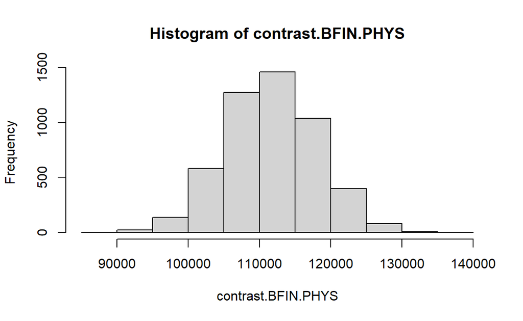

```r
contrast.BFIN.PHYS <- fit_ext.b2[,"BFIN"]-fit_ext.b2[,"PHYS"]
hist(contrast.BFIN.PHYS)
```

```r
mean(contrast.BFIN.PHYS)
```

```
[1] 111653.5
```

```r
hdi(contrast.BFIN.PHYS)
```

```
    lower     upper
 99528.41 124555.65
attr(,"credMass")
[1] 0.95
```

**What do we conclude about the differences of salaries?**

Plot histograms of salaries for both departments. Salaries `BFINComp` of Business and Finance and `PHYSComp` of Physics are calculate as described above.

```r
BFINComp <- fit_ext.b2[,"BFIN"]
PHYSComp <- fit_ext.b2[,"PHYS"]
```

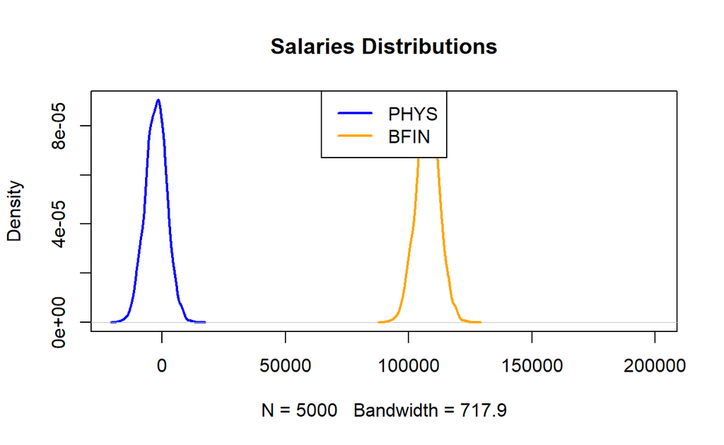

```r
distrBFIN <- density(BFINComp)
distrPHYS <- density(PHYSComp)

plot(distrPHYS,xlim=c(-20000,200000), lwd=2, main="Salaries Distributions", col="blue")
lines(distrBFIN$x, distrPHYS$y, lwd=2, col="orange")
legend("top", legend = c("PHYS","BFIN"), col = c("blue","orange"), lty=1, lwd=2)
```

Do the same comparison for finance professors and chemistry professors.

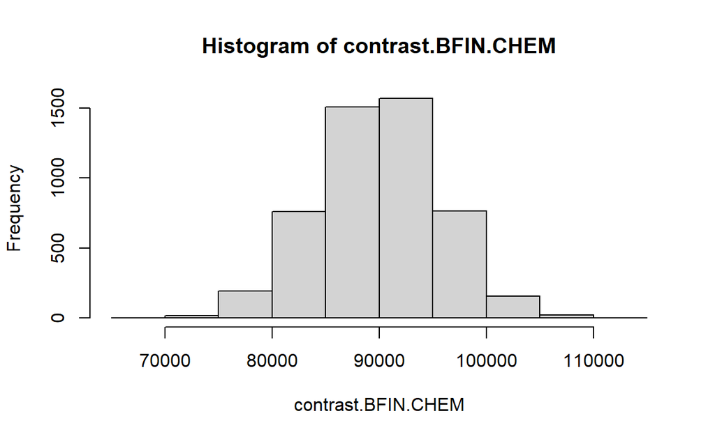

```r
contrast.BFIN.CHEM<-fit_ext.b2[,"BFIN"]-fit_ext.b2[,"CHEM"]
hist(contrast.BFIN.CHEM)
```

```r
mean(contrast.BFIN.CHEM)
```

```
[1] 89933.55
```

```r
hdi(contrast.BFIN.CHEM)
```

```
    lower     upper
 78655.11 101160.71
attr(,"credMass")
[1] 0.95
```

```r
BFINComp <- fit_ext.b2[,"BFIN"]
CHEMComp <- fit_ext.b2[,"CHEM"]
```

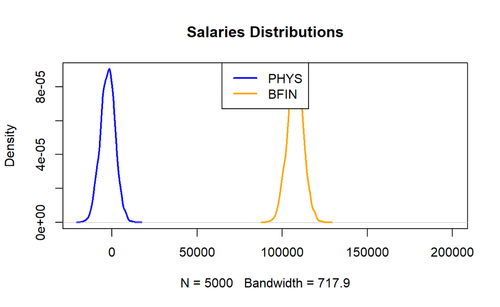

```r
distrBFIN <- density(BFINComp)
distrPHYS <- density(PHYSComp)

plot(distrPHYS,xlim=c(-20000,200000), lwd=2, main="Salaries Distributions", col="blue")
lines(distrBFIN$x, distrPHYS$y, lwd=2, col="orange")
legend("top", legend = c("PHYS","BFIN"), col = c("blue","orange"), lty=1, lwd=2)
```

### Contrast for comparison of positions

Use contrasts to compare salaries of Endowment Full Professor (“NDW”) and Distinguished Full Professor (“DST”). Compare salaries of Full Professor (“FT1”) and Endowment Full Professor

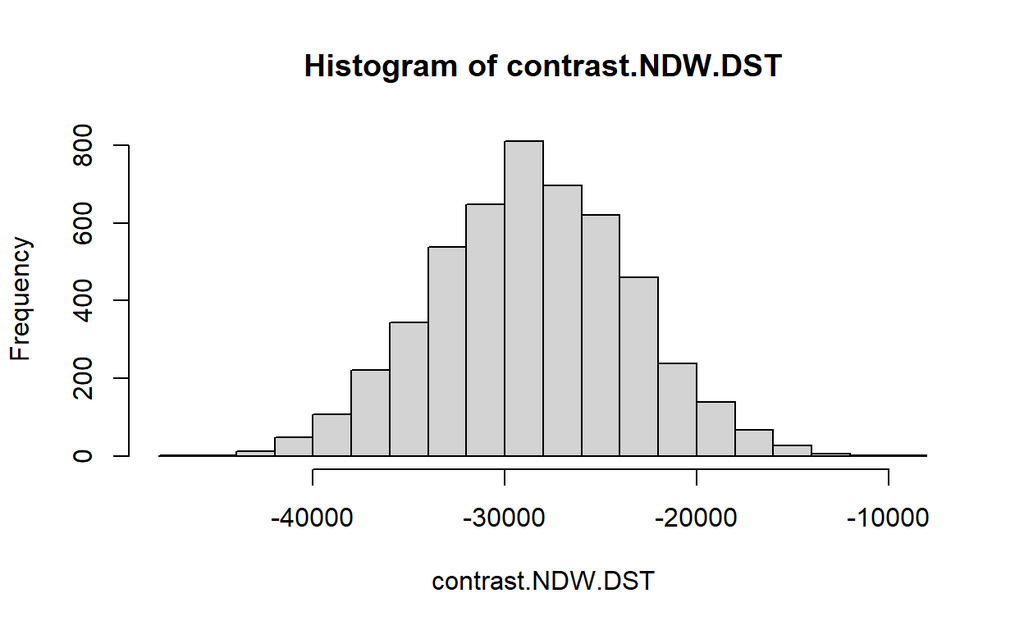

```r
contrast.NDW.DST <- fit_ext.b1[,"NDW"] - fit_ext.b1[,"DST"]
hist(contrast.NDW.DST)
```

```r
mean(contrast.NDW.DST)
```

```
[1] -28579.3
```

```r
hdi(contrast.NDW.DST)
```

```
    lower     upper
-38342.94 -17938.62
attr(,"credMass")
[1] 0.95
```

[figure not shown]

```r
DSTComp <- fit_ext.b1[,"NDW"]
NDWComp <- fit_ext.b1[,"DST"]

distrDST<-density(DSTComp)
distrNDW<-density(NDWComp)
plot(distrDST,xlim=c(14000,80000),lwd=2,main="Salaries Distributions",col="blue")
lines(distrNDW$x,distrPHYS$y,lwd=2,col="orange")
legend("top",legend=c("DST","NDW"),col=c("blue","orange"),lty=1,lwd=2)
```

Salary of a Distinguished Full Professor is significantly higher than salary of Endowment Full Professor.

Analyze difference between salaries of Full Professor (“FT1”) and Endowment Full Professor

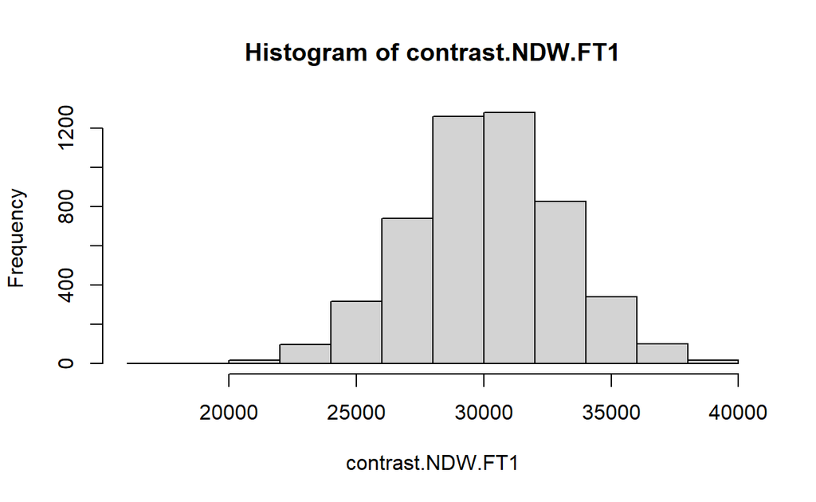

```r
contrast.NDW.FT1<-fit_ext.b1[,"NDW"]-fit_ext.b1[,"FT1"]
hist(contrast.NDW.FT1)
```

```r
mean(contrast.NDW.FT1)
```

```
[1] 30070.41
```

```r
hdi(contrast.NDW.FT1)
```

```
   lower    upper
23860.41 35549.30
attr(,"credMass")
[1] 0.95
```

### Contrast for comparison of spreads

Use contrasts to compare salaries spreads between Full Professor and Assistant Professor at Physics Department and at Chemistry Department.

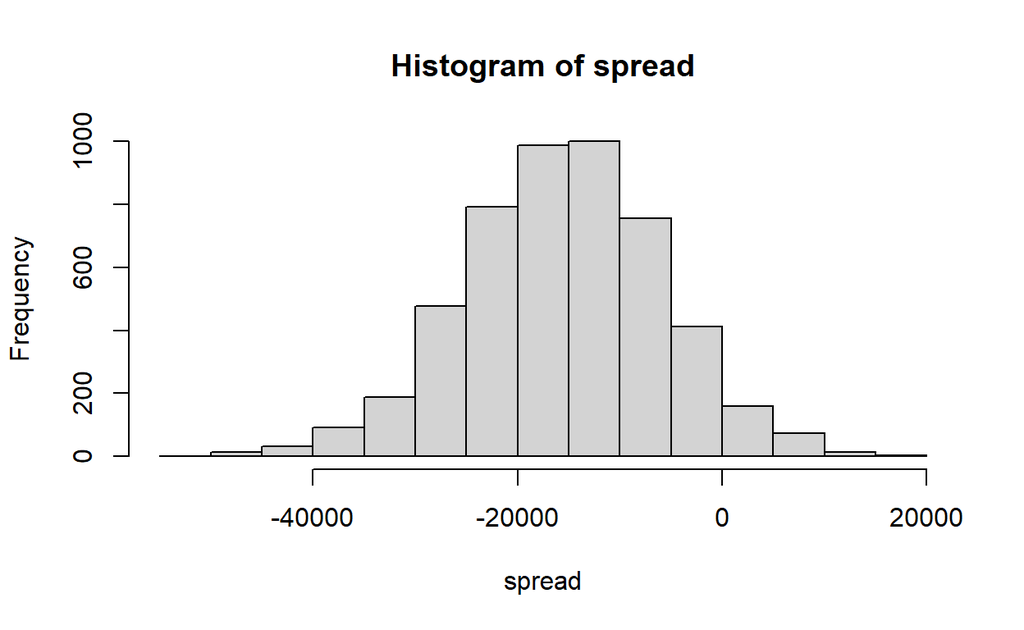

```r
spreadPhys<-fit_ext.b1[,"FT1"]+fit_ext.b1.b2[,"FT1","PHYS"]-
  (fit_ext.b1[,"FT3"]+fit_ext.b1.b2[,"FT3","PHYS"])
spreadChem<-fit_ext.b1[,"FT1"]+fit_ext.b1.b2[,"FT1","CHEM"]-
  (fit_ext.b1[,"FT3"]+fit_ext.b1.b2[,"FT3","CHEM"])
spread<-spreadPhys-spreadChem
hist(spread)
```

```r
mean(spread)
```

```
[1] -15530.47
```

```r
hdi(spread)
```

```
     lower      upper
-35565.326   3157.709
attr(,"credMass")
[1] 0.95
```

Find the highest HDI level for which the spread of differences between “FT1” and “FT3” is significant.

```r
hdi(spread,.88)
```

```
      lower       upper
-30176.5124   -661.9843
attr(,"credMass")
[1] 0.88
```

```r
tryLevels<-seq(from=.8,to=.95,by=.01)
hdis<-sapply(tryLevels,function(z) hdi(spread,z))
maxLevel<-tail(tryLevels[hdis[2,]<0],1)
hdi(spread,maxLevel)
```

```
      lower       upper
-30176.5124   -661.9843
attr(,"credMass")
[1] 0.88
```

## Understanding the effect of scaling and transformations on interactions

Nonlinear transformations may affect interactions very significantly.

Illustrate it on a simple simulated example.

```r
mean00<-1
mean10<-3
mean01<-4
mean11<-6
y00<-rnorm(5,mean00,.1)
y10<-rnorm(5,mean10,.1)
y01<-rnorm(5,mean01,.1)
y11<-rnorm(5,mean11,.1)
```

Plot the effects. If the lines are parallel the effects are additive.

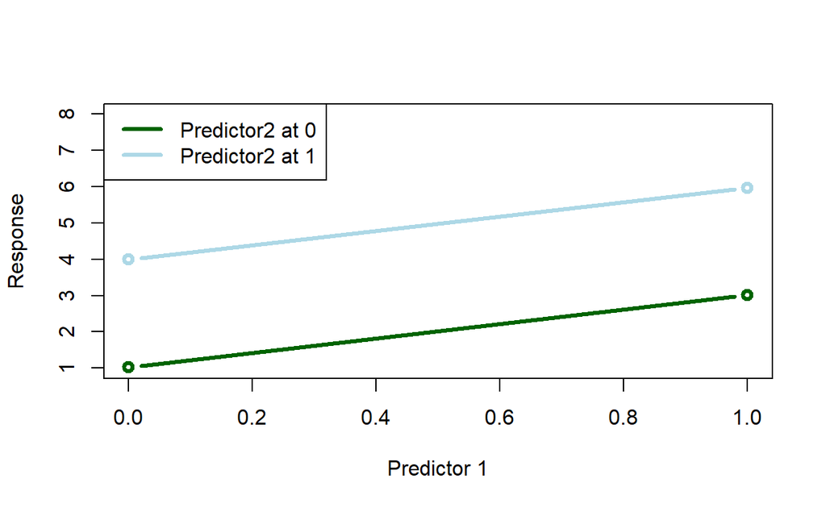

```r
plot(c(0,1),c(mean(y00),mean(y10)),type="b",ylim=c(1,8),col="darkgreen",lwd=3,ylab="Response",xlab="Predictor 1")
lines(c(0,1),c(mean(y01),mean(y11)),type="b",col="lightblue",lwd=3)
legend("topleft",legend=c("Predictor2 at 0","Predictor2 at 1"),lty=1,lwd=3,col=c("darkgreen","lightblue"))
```

Taking exponent of the same data introduces significant interaction.

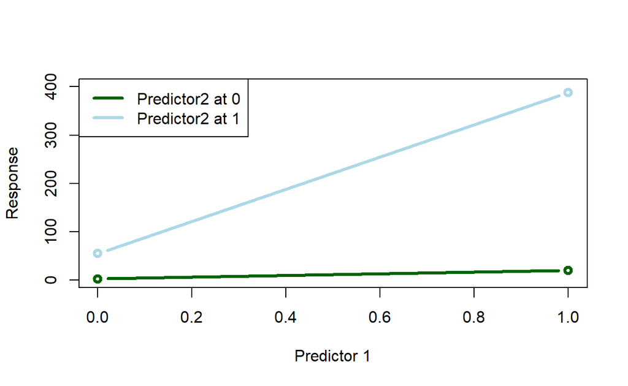

```r
plot(c(0,1),c(mean(exp(y00)),mean(exp(y10))),type="b",ylim=c(1,400),col="darkgreen",lwd=3,ylab="Response",xlab="Predictor 1")
lines(c(0,1),c(mean(exp(y01)),mean(exp(y11))),type="b",col="lightblue",lwd=3)
legend("topleft",legend=c("Predictor2 at 0","Predictor2 at 1"),lty=1,lwd=3,col=c("darkgreen","lightblue"))
```

# ANCOVA

## Traditional analysis

We cannot use `aov` in ANCOVA because it uses Type I SS, instead we should use Type II SS to get the correct results.

```r
longevity.aov2 <- aov(Longevity ~ CompanionNumber + Thorax, data = dta)
# car Anova command on our longevity.aov2 object,
#summary(longevity.aov2) #produces incorrect results
Anova(longevity.aov2, type="II")
```

```
Anova Table (Type II tests)

Response: Longevity
                 Sum Sq  Df F value    Pr(>F)
CompanionNumber  9611.5   4  21.753 1.719e-13 ***
Thorax          13168.9   1 119.219 < 2.2e-16 ***
Residuals       13144.7 119
---
Signif. codes:  0 '***' 0.001 '**' 0.01 '*' 0.05 '.' 0.1 ' ' 1
```

The covariate, `Thorax`, was significantly related to the fly’s longevity, F(1,119)=119.22, p<.001. There was also a significant effect of the Companion Number on the Longevity after controlling for the effect of the Thorax, F(4,119)=21.753, p<.001.